# nlme_rladies

CCusack

2023-07-23

- data from Aaron Fisher https://osf.io/nt37e/

# 1 libs dat

```r
#### my almost always packages ####
if (!require("psych")) {install.packages("psych"); require("psych")}
if (!require("tidyverse")) {install.packages("tidyverse"); require("tidyverse")}

#### data wrangling packages ####
if (!require("purrr")) {install.packages("purrr"); require("purrr")}
if (!require("sjmisc")) {install.packages("sjmisc"); require("sjmisc")}
if (!require("DataCombine")) {install.packages("DataCombine"); require("DataCombine")}
if (!require("data.table")) {install.packages("data.table"); require("data.table")}
if (!require("plyr")) {install.packages("plyr"); require("plyr")}

#### mlm packages ####
if (!require("nlme")) {install.packages("nlme"); require("nlme")} # mixed effects models
if (!require("psychometric")) {install.packages("psychometric"); require("psychometric")} # iccs
if (!require("r2mlm")) {install.packages("r2mlm"); require("r2mlm")} # pseudo-r squared

dat <- read.csv("mlm_dat.csv")
dim(dat) # 10217 x 32
```

```
## [1] 10217    32
```

```r
length(unique(dat$ID)) # 79
```

```
## [1] 79
```

# 2 data management

## 2.1 night lags

Here, I:  
1. **add an empty row** after the last beep of the day to account for night lags  
2. **fill in the ID and date** from the row above  
3. **remove the last empty row** for each participant (e.g., remove the empty row btween ID_001 and ID_003)  
4. **renumber beeps**

```r
dat <- dat %>%
  group_split(ID, dayvar) %>%
  map_dfr(~ add_row(.x, .after = Inf))

dat <- dat %>% tidyr::fill(ID, date)
dat <- dat %>% group_by(ID) %>% slice(-n())

dat <- dat %>% group_by(ID) %>%
  dplyr::mutate(beepconsec = seq(1:n())) %>%
  ungroup()
```

## 2.2 btwn and within

In these code chunks, I create “trait” like variables for the mean. Then, I center them. I create “state” like variables that subtract their trait-like variable from their momentary value. Then, I lag variables (shit down one row.)

### 2.2.1 trait vars

```r
dat_means <- dat %>% group_by(ID) %>%
summarise_at(vars(energetic:avoid_people), mean, na.rm=TRUE)

colnames(dat_means)[c(2:ncol(dat_means))] <- paste(colnames(dat_means)[c(2:ncol(dat_means))],"trait",sep="_")

dat <- merge(dat, dat_means, by="ID")
```

### 2.2.2 center trait vars

```r
dat <- dat %>%
  mutate_at(vars(ends_with("trait")),  list(mod = ~ scale(., center=TRUE, scale=FALSE))) %>%
  rename_at(vars(ends_with("_mod")), list(~ paste(gsub("_mod", "_cent", .))))
```

### 2.2.3 create state vars

```r
# there's definitely a more elegant solution, but here we are
xx = colnames(dat[c(which(colnames(dat)=="energetic"):which(colnames(dat)=="avoid_people"))])
xx <- paste(xx, "state", sep = "_")
dat[xx] <- NA

dat <- dat %>%
  mutate(energetic_state = energetic - energetic_trait) %>%
  mutate(enthusiastic_state = enthusiastic - enthusiastic_trait) %>%
  mutate(content_state = content - content_trait) %>%
  mutate(irritable_state = irritable - irritable_trait) %>%
  mutate(restless_state = restless - restless_trait) %>%
  mutate(worried_state = worried - worried_trait) %>%
  mutate(guilty_state = guilty - guilty_trait) %>%
  mutate(afraid_state = afraid - afraid_trait) %>%
  mutate(anhedonia_state = anhedonia - anhedonia_trait) %>%
  mutate(angry_state = angry - angry_trait) %>%
  mutate(hopeless_state = hopeless - hopeless_trait) %>%
  mutate(down_state = down - down_trait) %>%
  mutate(positive_state = positive - positive_trait) %>%
  mutate(fatigue_state = fatigue - fatigue_trait) %>%
  mutate(tension_state = tension - tension_trait) %>%
  mutate(concentrate_state = concentrate - concentrate_trait) %>%
  mutate(accepted_state = accepted - accepted_trait) %>%
  mutate(threatened_state = threatened - threatened_trait) %>%
  mutate(ruminate_state = ruminate - ruminate_trait) %>%
  mutate(avoid_act_state = avoid_act - avoid_act_trait) %>%
  mutate(reassure_state = reassure - reassure_trait) %>%
  mutate(procrast_state = procrast - procrast_trait) %>%
  mutate(hours_state = hours - hours_trait) %>%
  mutate(difficult_state = difficult - difficult_trait) %>%
  mutate(unsatisfy_state = unsatisfy - unsatisfy_trait) %>%
  mutate(avoid_people_state = avoid_people - avoid_people_trait)
```

### 2.2.4 lag

```r
namesoriginal <- names(dat[c(which(colnames(dat)=="energetic"):which(colnames(dat)=="avoid_people"))]) # save original names in a vector
nameslag <- paste(names(dat[c(which(colnames(dat)=="energetic"):which(colnames(dat)=="avoid_people"))]), "_lag", sep="") # save new names in a vector

list <- split(dat, dat$ID) # split df by id

list  <- list %>%  # shift all list elements with columns in name original
  map(~shift(.x[namesoriginal],  n = -1, fill=NA, type="lead"))

for(i in seq_along(list)){ # make each list element a dataframe
  list[[i]] <- do.call("cbind", list[[i]])
}

lagdf <- ldply(list, data.frame) # list as dataframe
names(lagdf) <- c("ID", nameslag) # rename vars
lagdf <- lagdf[-1] # remove ID col

dat <- cbind(dat, lagdf) # add lagged vars to dataframe

# clean up environment
rm(list, lagdf, namesoriginal, nameslag, i)

# save df
write.csv(dat, "mlm_dat_processed.csv", row.names = FALSE)
```

# 3 if you start here with preproccesed dat

```r
rm(list=ls())
#### my almost always packages ####
if (!require("psych")) {install.packages("psych"); require("psych")}
if (!require("tidyverse")) {install.packages("tidyverse"); require("tidyverse")}

#### data wrangling packages ####
if (!require("purrr")) {install.packages("purrr"); require("purrr")}
if (!require("sjmisc")) {install.packages("sjmisc"); require("sjmisc")}
if (!require("DataCombine")) {install.packages("DataCombine"); require("DataCombine")}
if (!require("data.table")) {install.packages("data.table"); require("data.table")}
if (!require("plyr")) {install.packages("plyr"); require("plyr")}

#### mlm packages ####
if (!require("nlme")) {install.packages("nlme"); require("nlme")} # mixed effects models
if (!require("psychometric")) {install.packages("psychometric"); require("psychometric")} # iccs
if (!require("r2mlm")) {install.packages("r2mlm"); require("r2mlm")} # pseudo-r squared
if (!require("insight")) {install.packages("insight"); require("insight")}
dat <- read.csv("mlm_dat_processed.csv")
```

# 4 brief data overview

We have 79 participants who completed an average of 129 surveys (*SD* = 16.67, Min = 103, Max = 213) across 55 days.

```r
head(dat)
```

|  | ID | date | time | dayvar | beepvar | beepconsec | energetic | enthusiastic | content | irritable | restless | worried | guilty | afraid | anhedonia | angry | hopeless | down | positive | fatigue | tension | concentrate | accepted | threatened | ruminate | avoid_act | reassure | procrast | hours | … |
| --- | --- | --- | --- | --- | --- | --- | --- | --- | --- | --- | --- | --- | --- | --- | --- | --- | --- | --- | --- | --- | --- | --- | --- | --- | --- | --- | --- | --- | --- | --- |
| 1 | ID_001 | 2014-10-21 | 17:55 | 1 | 1 | 1 | 19 | 23 | 33 | 74 | 89 | 87 | 72 | 70 | 74 | 64 | 78 | 85 | 44 | 94 | 17 | 84 | 16 | 75 | 100 | 72 | 88 | 83 | 8 | … |
| 2 | ID_001 | 2014-10-21 | 21:20 | 1 | 2 | 2 | NA | NA | NA | NA | NA | NA | NA | NA | NA | NA | NA | NA | NA | NA | NA | NA | NA | NA | NA | NA | NA | NA | NA | … |
| 3 | ID_001 | 2014-10-21 | NA | NA | NA | 3 | NA | NA | NA | NA | NA | NA | NA | NA | NA | NA | NA | NA | NA | NA | NA | NA | NA | NA | NA | NA | NA | NA | NA | … |
| 4 | ID_001 | 2014-10-22 | 13:38 | 2 | 1 | 4 | NA | NA | NA | NA | NA | NA | NA | NA | NA | NA | NA | NA | NA | NA | NA | NA | NA | NA | NA | NA | NA | NA | NA | … |
| 5 | ID_001 | 2014-10-22 | 17:44 | 2 | 2 | 5 | 37 | 31 | 25 | 60 | 66 | 60 | 65 | 27 | 51 | 8 | 55 | 55 | 41 | 65 | 36 | 73 | 58 | 56 | 59 | 50 | 58 | 55 | NA | … |
| 6 | ID_001 | 2014-10-22 | 21:40 | 2 | 3 | 6 | 20 | 39 | 40 | 55 | 53 | 70 | 63 | 17 | 37 | 34 | 65 | 57 | 39 | 64 | 32 | 80 | 62 | 60 | 86 | 9 | 50 | 58 | NA | … |

```r
# note data are in long form. Each observation is it's own row. This form contrasts wide-format where each participant is it's own row and may have multiple time points as columns
```

Summary stats for study. For EMA studies, want to report participants and how many observations are within participants.

```r
# number of unique participants
length(unique(dat$ID)) # 79
```

```
## [1] 79
```

```r
dat %>%
  filter(!is.na(time)) %>%  # exclude time lag rows
  group_by(ID) %>% # group by participant
  tally() %>% # survey count by participant
  summarise(meanobs = mean(n), median(n), sdobs=sd(n), minobs=min(n), maxobs=max(n))
```

| meanobs | median(n) | sdobs | minobs | maxobs |
| --- | --- | --- | --- | --- |
| 129.3291 | 125 | 16.6662 | 103 | 213 |

```r
# Participants completed an average of 129 surveys (SD = 16.67). Minimum number of surveys = 103, maximum surveys = 213.

describe(dat[c(which(colnames(dat)=="dayvar"), which(colnames(dat)=="beepvar"))]) # maximum of 55 days, max beep var is 5 but I know I added an empty row between last beep and first beep so actually 4 pings per day
```

|  | vars | n | mean | sd | median | trimmed | mad | min | max | range | skew | kurtosis | se |
| --- | --- | --- | --- | --- | --- | --- | --- | --- | --- | --- | --- | --- | --- |
| dayvar | 1 | 10217 | 17.620534 | 9.996308 | 17 | 17.356575 | 11.8608 | 1 | 55 | 54 | 0.25275776 | -0.6032703 | 0.09889582 |
| beepvar | 2 | 10217 | 2.462269 | 1.115391 | 2 | 2.452355 | 1.4826 | 1 | 5 | 4 | 0.04837407 | -1.3460832 | 0.01103483 |

## 4.1 visualize variables

before you model, it’s good to have a sense of the shape of your data. I visualize histogram below. skimr::skimr also is good/easy for this purpose.

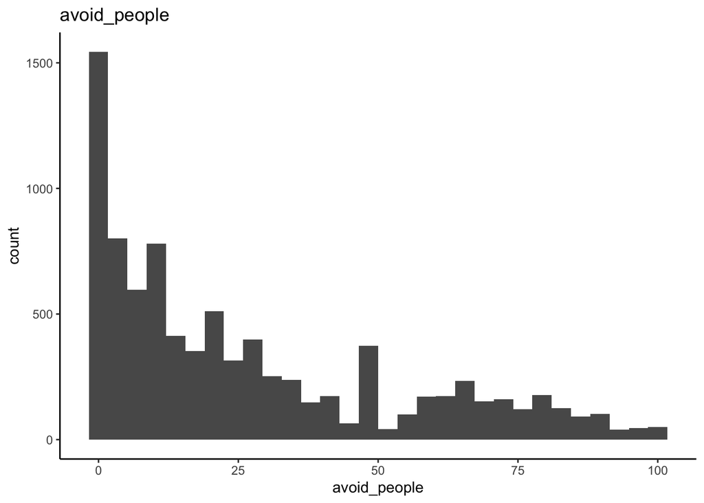

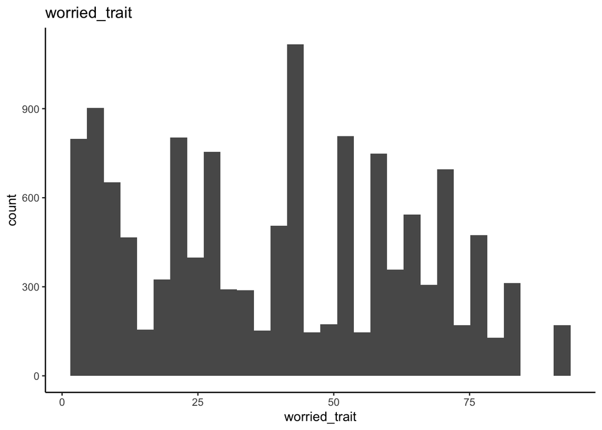

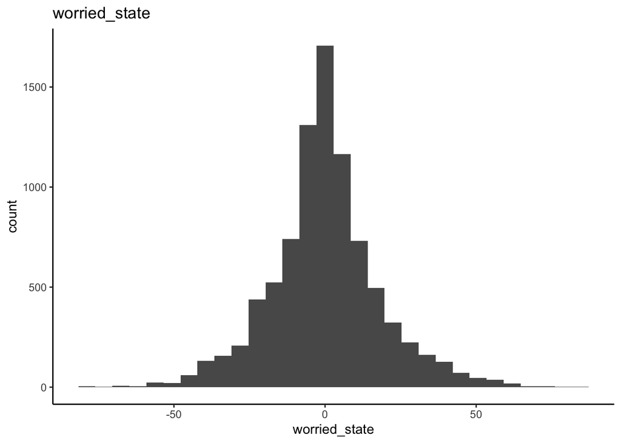

```r
dens_fun <- function(var, name) {
  ggplot(dat, aes(x = var)) +
    geom_histogram() +
    theme_classic() +
    labs(x = name,
         title = name)
}

dat %>%
  dplyr::select(avoid_people, worried_trait, worried_state) %>%
  map2(.y = names(.),
       ~ dens_fun(.x, .y)
  )
```

```r
library(skimr)
skim(dat[c(which(colnames(dat)=="avoid_people"), which(colnames(dat)=="worried_trait"), which(colnames(dat)=="worried_state"))])
```

Data summary

| Name | …[] |
| --- | --- |
| Number of rows | 12794 |
| Number of columns | 3 |
| _______________________ |  |
| Column type frequency: |  |
| numeric | 3 |
| ________________________ |  |
| Group variables | None |

**Variable type: numeric**

| skim_variable | n_missing | complete_rate | mean | sd | p0 | p25 | p50 | p75 | p100 | hist |
| --- | --- | --- | --- | --- | --- | --- | --- | --- | --- | --- |
| avoid_people | 4039 | 0.68 | 27.00 | 27.11 | 0.00 | 5.00 | 18.00 | 45.00 | 100.00 | ▇▃▂▂▁ |
| worried_trait | 0 | 1.00 | 39.43 | 24.57 | 2.12 | 19.45 | 40.35 | 59.57 | 91.08 | ▇▆▇▇▂ |
| worried_state | 4039 | 0.68 | 0.00 | 18.23 | -76.80 | -9.55 | -1.06 | 8.90 | 86.44 | ▁▂▇▁▁ |

# 5 ICC

```r
#### ICC ####
ICC1.lme(avoid_people_lag, ID, data=dat) # 0.49 variance is at the btwn person level
```

```
## [1] 0.4914936
```

# 6 Random-intercept only

```r
avoid_RE = lme(avoid_people_lag ~ 1,
            random =~ 1|ID,
            data=dat,
            method="ML",
            na.action = na.exclude)

summary(avoid_RE)
```

```
## Linear mixed-effects model fit by maximum likelihood
##   Data: dat
##        AIC      BIC    logLik
##   76590.35 76611.56 -38292.17
##
## Random effects:
##  Formula: ~1 | ID
##         (Intercept) Residual
## StdDev:    19.02845 19.47988
##
## Fixed effects:  avoid_people_lag ~ 1
##                Value Std.Error   DF  t-value p-value
## (Intercept) 27.18876  2.151258 8605 12.63854       0
##
## Standardized Within-Group Residuals:
##        Min         Q1        Med         Q3        Max
## -3.2445883 -0.5506855 -0.1150582  0.3577556  4.9148006
##
## Number of Observations: 8684
## Number of Groups: 79
```

```r
# average avoidance score is 27.19
# within-person effect is 19.03 (how much individuals vary from grand mean)
# number of groups and observations, does it match what you expect?
```

### 6.0.1 RE with AR(1) correlation structure

```r
avoid_RE1 = lme(avoid_people_lag ~ 1,
            random =~ 1|ID,
            data=dat,
            correlation = corCAR1(form=~beepconsec),
            method="ML",
            na.action = na.exclude)
summary(avoid_RE1)
```

```
## Linear mixed-effects model fit by maximum likelihood
##   Data: dat
##        AIC      BIC    logLik
##   76020.37 76048.65 -38006.18
##
## Random effects:
##  Formula: ~1 | ID
##         (Intercept) Residual
## StdDev:    18.96952  19.5658
##
## Correlation Structure: Continuous AR(1)
##  Formula: ~beepconsec | ID
##  Parameter estimate(s):
##       Phi
## 0.3162552
## Fixed effects:  avoid_people_lag ~ 1
##                Value Std.Error   DF  t-value p-value
## (Intercept) 27.18331  2.150627 8605 12.63971       0
##
## Standardized Within-Group Residuals:
##        Min         Q1        Med         Q3        Max
## -3.2119210 -0.5504134 -0.1245835  0.3441978  4.8870151
##
## Number of Observations: 8684
## Number of Groups: 79
```

```r
# the average avoidance score is 27.18 with an SD in individual scores being 2.15
# random effect (within person diff) = 18.97 (how much individuals vary from fixed effect);
# between person diff 19.57 is how much individuals vary from each other
intervals(avoid_RE1)
```

```
## Approximate 95% confidence intervals
##
##  Fixed effects:
##                lower     est.    upper
## (Intercept) 22.96781 27.18331 31.39881
##
##  Random Effects:
##   Level: ID
##                   lower     est.    upper
## sd((Intercept)) 16.1929 18.96952 22.22226
##
##  Correlation structure:
##         lower      est.     upper
## Phi 0.2934551 0.3162552 0.3399745
##
##  Within-group standard error:
##    lower     est.    upper
## 19.25396 19.56580 19.88269
```

```r
# if CI contains zero, random effects null

anova(avoid_RE, avoid_RE1) # here we see adding the AR1 correlation structure results in a better model fit
```

|  | call | Model | df | AIC | BIC | logLik | Test | L.Ratio | p-value |
| --- | --- | --- | --- | --- | --- | --- | --- | --- | --- |
| avoid_RE | lme.formula(fixed = avoid_people_lag ~ 1, data = dat, random = ~1 \| ID, method = "ML", na.action = na.exclude) | 1 | 3 | 76590.35 | 76611.56 | -38292.17 |  | NA | NA |
| avoid_RE1 | lme.formula(fixed = avoid_people_lag ~ 1, data = dat, random = ~1 \| ID, correlation = corCAR1(form = ~beepconsec), method = "ML", na.action = na.exclude) | 2 | 4 | 76020.37 | 76048.65 | -38006.18 | 1 vs 2 | 571.9797 | 2.082953e-126 |

# 7 add fixed effects

add in worry as both between-person (`worried_trait`) and within-person (`worrired_state`) predictor

Is avoiding people a function of general and momentary worry?

```r
avoid_anx1 = lme(avoid_people_lag ~ worried_trait + worried_state,
            random =~ 1|ID,
            data=dat,
            correlation= corCAR1(form=~beepconsec),
            method="ML", # maximum likelihood estimation
            na.action = "na.omit")
summary(avoid_anx1)
```

```
## Linear mixed-effects model fit by maximum likelihood
##   Data: dat
##        AIC      BIC    logLik
##   49095.85 49135.65 -24541.92
##
## Random effects:
##  Formula: ~1 | ID
##         (Intercept) Residual
## StdDev:    13.24941 19.34278
##
## Correlation Structure: Continuous AR(1)
##  Formula: ~beepconsec | ID
##  Parameter estimate(s):
##       Phi
## 0.3230153
## Fixed effects:  avoid_people_lag ~ worried_trait + worried_state
##                  Value Std.Error   DF  t-value p-value
## (Intercept)   5.716603 2.8464986 5534 2.008293  0.0447
## worried_trait 0.549054 0.0618329   77 8.879641  0.0000
## worried_state 0.063456 0.0143487 5534 4.422445  0.0000
##  Correlation:
##               (Intr) wrrd_t
## worried_trait -0.845
## worried_state  0.001 -0.002
##
## Standardized Within-Group Residuals:
##        Min         Q1        Med         Q3        Max
## -3.1108059 -0.5226382 -0.1288271  0.3605832  4.7329860
##
## Number of Observations: 5614
## Number of Groups: 79
```

```r
# fixed effects: the between person effect is much stronger than within person effect.
# For each unit increase in momentary worry, avoiding people increases by 0.06. For each unit increase in avg worry, avoiding people increases by 0.55.
```

## 7.1 confidence intervals fixed effects

```r
intervals(avoid_anx1)
```

```
## Approximate 95% confidence intervals
##
##  Fixed effects:
##                    lower       est.      upper
## (Intercept)   0.13783903 5.71660303 11.2953670
## worried_trait 0.42596176 0.54905388  0.6721460
## worried_state 0.03533465 0.06345613  0.0915776
##
##  Random Effects:
##   Level: ID
##                    lower     est.    upper
## sd((Intercept)) 11.25686 13.24941 15.59466
##
##  Correlation structure:
##         lower      est.     upper
## Phi 0.2892461 0.3230153 0.3587372
##
##  Within-group standard error:
##    lower     est.    upper
## 18.95616 19.34278 19.73729
```

```r
# coef(avoid_anx1) # here we can see our fixed effects are constant and our intercepts vary by participant
```

## 7.2 pseudo- r squared

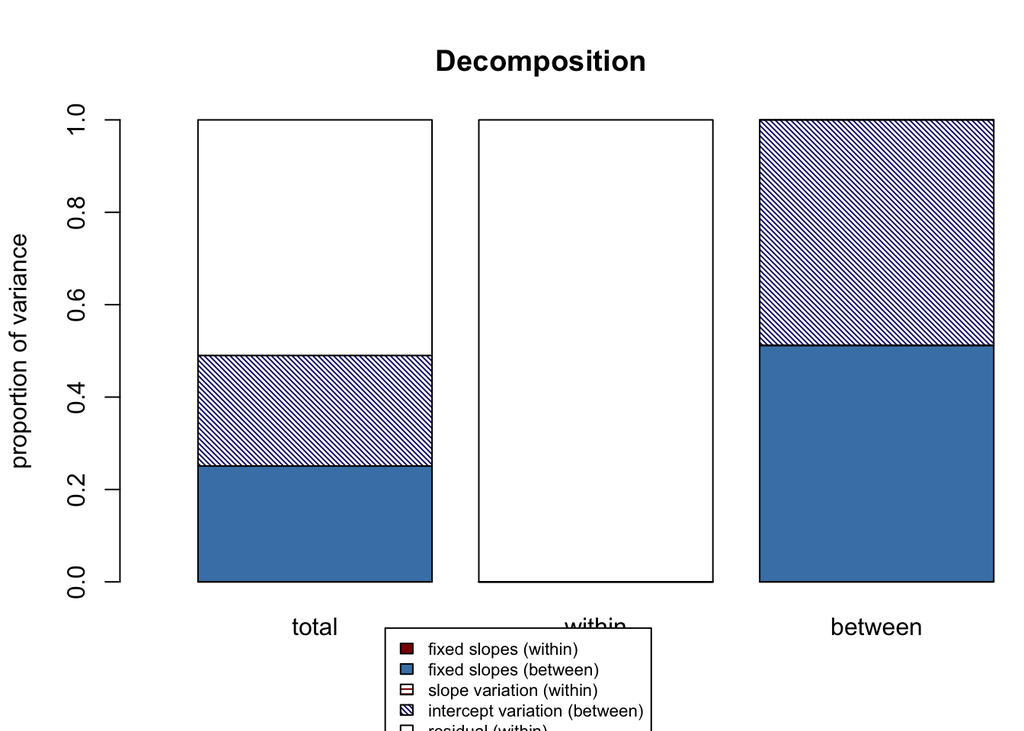

```
## $Decompositions
##                     total within   between
## fixed, within   0.0000000      0        NA
## fixed, between  0.2507557     NA 0.5117135
## slope variation 0.0000000      0        NA
## mean variation  0.2392758     NA 0.4882865
## sigma2          0.5099685      1        NA
##
## $R2s
##         total within   between
## f1  0.0000000      0        NA
## f2  0.2507557     NA 0.5117135
## v   0.0000000      0        NA
## m   0.2392758     NA 0.4882865
## f   0.2507557     NA        NA
## fv  0.2507557      0        NA
## fvm 0.4900315     NA        NA
```

```r
r2mlm(avoid_anx1, bargraph = TRUE)
```

```r
# fvm represents the total outcome variance explained by predictors through fixed slopes and random slope variation/covariation and between-person random intercept variation (e.g., total R2 measure; R2total) 0.4903065
# 2) v represents the proportion of outcome variance explained by predictors via random slope variation/covariation (e.g., within-person R2 measure; R2within); 0.00
# 3) f2 represents the proportion outcome variance explained by between-person variables fixed slopes (e.g., between-person R2 measure; R2between) .25
```

## 7.3 assumptions

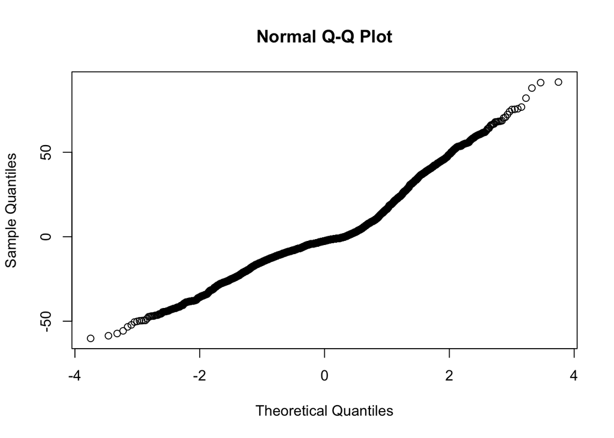

```r
qqnorm(residuals(avoid_anx1)) # normality of resid
```

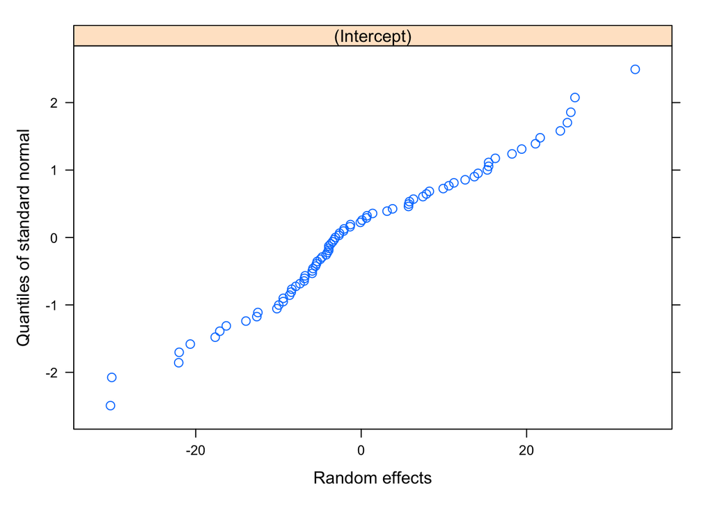

```r
qqnorm(avoid_anx1, ~ranef(., level=1)) # normality of random effects
```

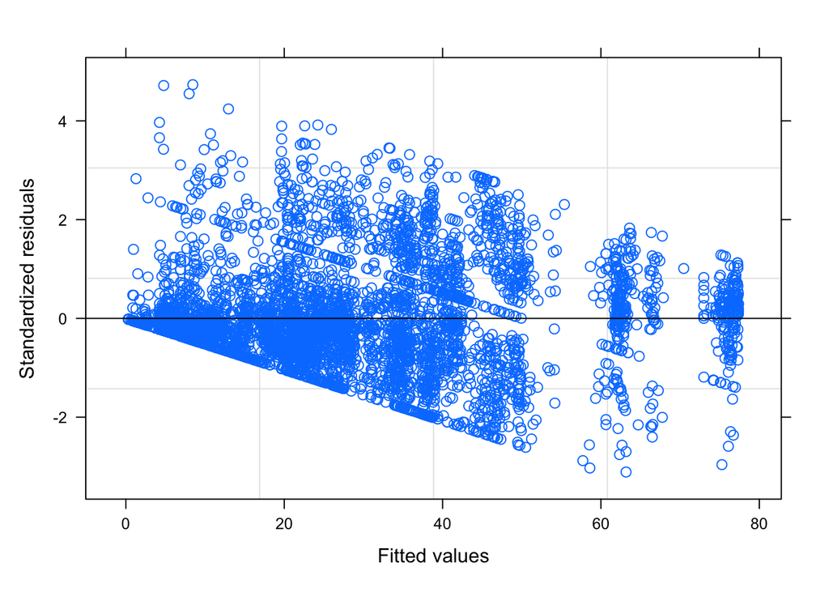

```r
plot(avoid_anx1)
```

# 8 add random effect for within-person associations

Let momentary worry vary across persons

```r
avoid_anx2 = lme(avoid_people_lag ~ worried_trait + worried_state,
            random =~ 1 + worried_state|ID,
            data=dat,
            correlation= corCAR1(form=~beepconsec),
            method="ML",
            na.action = "na.omit")

summary(avoid_anx2)
```

```
## Linear mixed-effects model fit by maximum likelihood
##   Data: dat
##        AIC      BIC    logLik
##   49074.69 49127.75 -24529.34
##
## Random effects:
##  Formula: ~1 + worried_state | ID
##  Structure: General positive-definite, Log-Cholesky parametrization
##               StdDev     Corr
## (Intercept)   13.2702130 (Intr)
## worried_state  0.1112982 0.19
## Residual      19.1895510
##
## Correlation Structure: Continuous AR(1)
##  Formula: ~beepconsec | ID
##  Parameter estimate(s):
##       Phi
## 0.3137038
## Fixed effects:  avoid_people_lag ~ worried_trait + worried_state
##                  Value Std.Error   DF  t-value p-value
## (Intercept)   6.139772 2.8388555 5534 2.162763  0.0306
## worried_trait 0.538552 0.0615847   77 8.744891  0.0000
## worried_state 0.077898 0.0203157 5534 3.834376  0.0001
##  Correlation:
##               (Intr) wrrd_t
## worried_trait -0.844
## worried_state  0.048  0.016
##
## Standardized Within-Group Residuals:
##        Min         Q1        Med         Q3        Max
## -3.3344886 -0.5188257 -0.1272190  0.3593518  4.7533645
##
## Number of Observations: 5614
## Number of Groups: 79
```

```r
# positive slope. pos correlation = .19 correlation btwn ind diff and the within person coupling. People w/ more people avoidance have a stronger association w/ avoidance and momentary worry
```

## 8.1 CIs

```r
intervals(avoid_anx2)
```

```
## Approximate 95% confidence intervals
##
##  Fixed effects:
##                   lower       est.      upper
## (Intercept)   0.5759871 6.13977160 11.7035561
## worried_trait 0.4159537 0.53855177  0.6611499
## worried_state 0.0380820 0.07789819  0.1177144
##
##  Random Effects:
##   Level: ID
##                                      lower       est.      upper
## sd((Intercept))                11.27812513 13.2702130 15.6141692
## sd(worried_state)               0.07821313  0.1112982  0.1583787
## cor((Intercept),worried_state) -0.09091056  0.1901963  0.4432305
##
##  Correlation structure:
##         lower      est.     upper
## Phi 0.2792875 0.3137038 0.3502997
##
##  Within-group standard error:
##    lower     est.    upper
## 18.80371 19.18955 19.58331
```

```r
get_variance(avoid_anx2)
```

```
## $var.fixed
## [1] 179.2372
##
## $var.random
## [1] 180.182
##
## $var.residual
## [1] 368.2389
##
## $var.distribution
## [1] 368.2389
##
## $var.dispersion
## [1] 0
##
## $var.intercept
##       ID
## 176.0986
##
## $var.slope
## ID.worried_state
##        0.0123873
##
## $cor.slope_intercept
##   ID
## 0.19
```

```r
# var fixed 179.2374 (variance attributed to FEs)
# var intercept 176.0984 (between subject variance)
# var random (mean variance of REs)
# var resid 368.2388 (residual variance)
# random slope variance .012
# cor.slope_intercept 0.19 (relation btwn random slope and intercept)
VarCorr(avoid_anx2)
```

```
## ID = pdLogChol(1 + worried_state)
##               Variance    StdDev     Corr
## (Intercept)   176.0985540 13.2702130 (Intr)
## worried_state   0.0123873  0.1112982 0.19
## Residual      368.2388662 19.1895510
```

```r
# variance/sd estimates for random effects. corr is the relation among REs within the same level of grouping
```

# 9 compare mods

```r
anova.lme(avoid_anx1, avoid_anx2) # avoid_anx2 has lower AIC and BIC values. model 2 is a better fit than model 1, we should let the random slopes vary
```

|  | call | Model | df | AIC | BIC | logLik | Test | L.Ratio | p-value |
| --- | --- | --- | --- | --- | --- | --- | --- | --- | --- |
| avoid_anx1 | lme.formula(fixed = avoid_people_lag ~ worried_trait + worried_state, data = dat, random = ~1 \| ID, correlation = corCAR1(form = ~beepconsec), method = "ML", na.action = "na.omit") | 1 | 6 | 49095.85 | 49135.65 | -24541.92 |  | NA | NA |
| avoid_anx2 | lme.formula(fixed = avoid_people_lag ~ worried_trait + worried_state, data = dat, random = ~1 + worried_state \| ID, correlation = corCAR1(form = ~beepconsec), method = "ML", na.action = "na.omit") | 2 | 8 | 49074.69 | 49127.75 | -24529.34 | 1 vs 2 | 25.16333 | 3.43442e-06 |

## 9.1 pseudo-rsquare

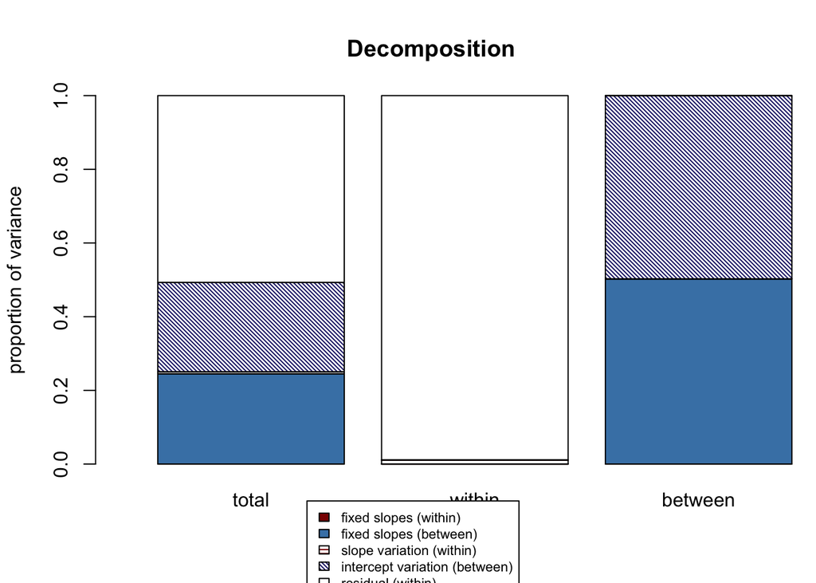

```
## $Decompositions
##                       total     within   between
## fixed, within   0.000000000 0.00000000        NA
## fixed, between  0.244742906         NA 0.5023026
## slope variation 0.005669371 0.01105662        NA
## mean variation  0.242499063         NA 0.4976974
## sigma2          0.507088661 0.98894338        NA
##
## $R2s
##           total     within   between
## f1  0.000000000 0.00000000        NA
## f2  0.244742906         NA 0.5023026
## m   0.242499063         NA 0.4976974
## f   0.244742906         NA        NA
## fv  0.250412277 0.01105662        NA
## fvm 0.492911339         NA        NA
```

```r
r2mlm(avoid_anx2, bargraph = TRUE)
```

```r
# fvm = 0.493176037
# v = 0.01
# f2 = 0.25
```

## 9.2 assumptions

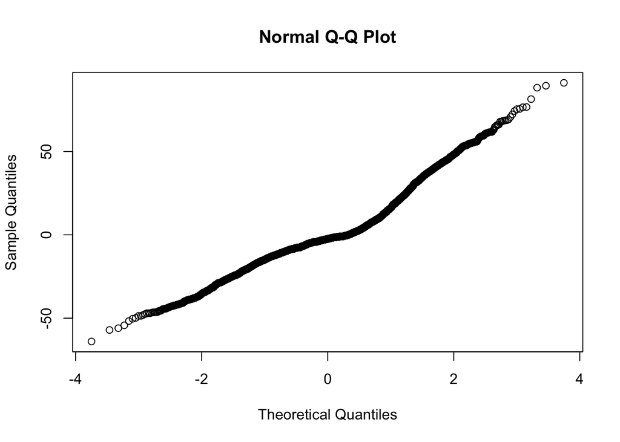

```r
qqnorm(residuals(avoid_anx2))
```

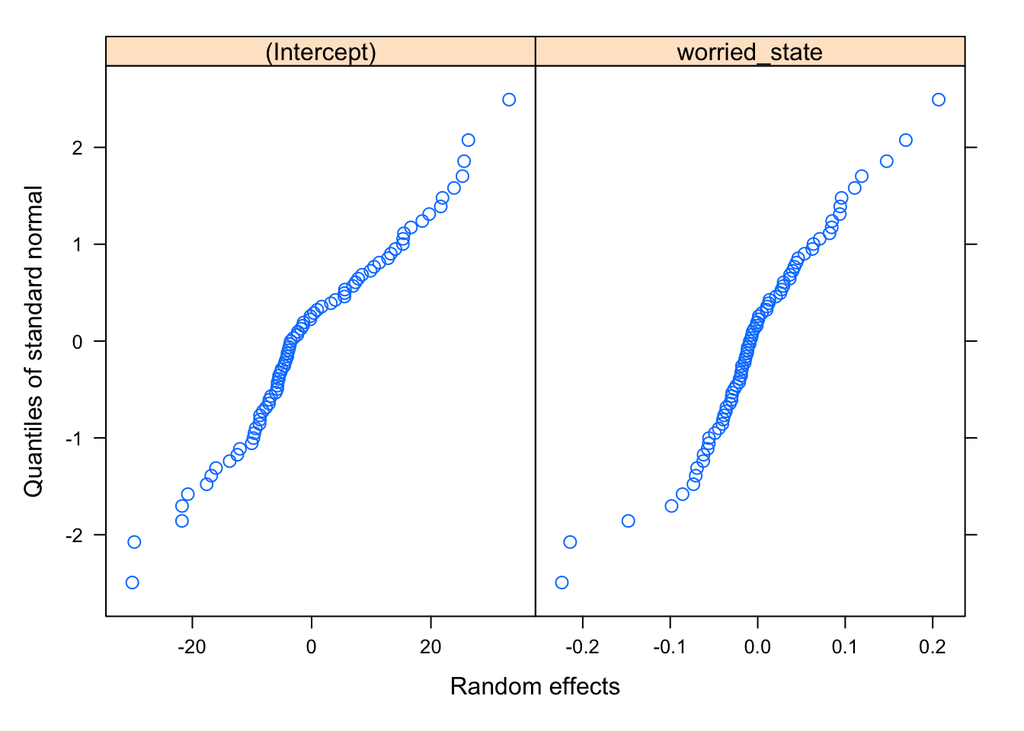

```r
qqnorm(avoid_anx2, ~ranef(., level=1))
```

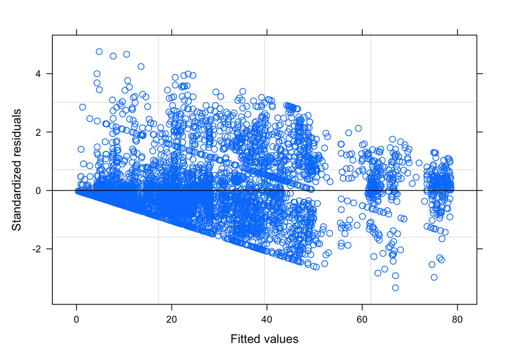

```r
plot(avoid_anx2)
```

# 10 plots

## 10.1 avoid people - worry trait

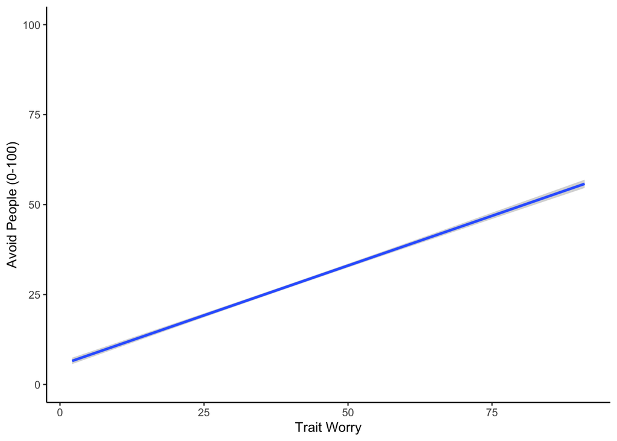

```r
# plotting avoid people by trait like worry
dat %>%
  filter(beepconsec<200) %>%
  ggplot(aes(worried_trait, avoid_people)) +
  geom_smooth(method='lm', se=TRUE) +
  # geom_point(color='black',size=.1) +
  labs(x = "Trait Worry", y = "Avoid People (0-100)") +
  theme_classic() +
  coord_cartesian(ylim=c(0,100))
```

## 10.2 momentary worry and avoid

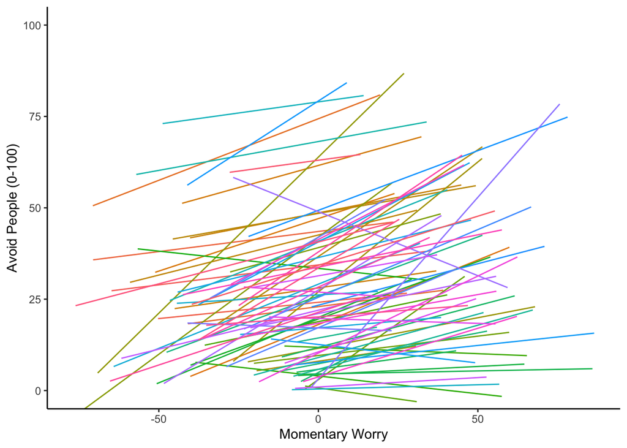

```r
dat %>%
  filter(beepconsec<200) %>%
  ggplot(aes(x=worried_state, y=avoid_people, group=ID, color=ID))+
  geom_smooth(method = "lm", se=FALSE, size=.5)+ # toggle se TRUE
  labs(x="Momentary Worry", y="Avoid People (0-100)") +
  theme_classic() +
  theme(legend.position = "none") +
  coord_cartesian(ylim=c(0,100))
```

## 10.3 momentary worry avoid facet

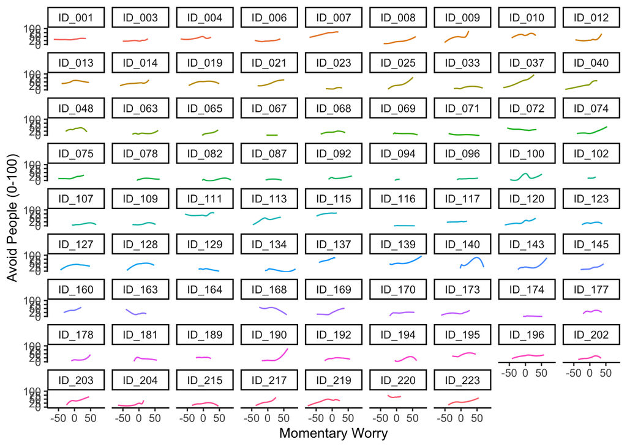

```r
# facet
dat %>%
  filter(beepconsec<200) %>%
  ggplot(aes(x=worried_state, y=avoid_people, group=ID, color=ID))+
  geom_smooth(method = "loess", se=FALSE, size=.5)+
  labs(x="Momentary Worry", y="Avoid People (0-100)") +
  theme_classic() +
  theme(legend.position = "none") +
  coord_cartesian(ylim=c(0,100)) +
  facet_wrap(~ID)  # generally people stay high or stay low
```